# Covid Assigment

Yuri Almeida Cunha

2020-11-28

# Executive Summary

On the following project, I checked the possible association between the number of confirmed Covid cases and their number of deaths associated with the disease by country on a given day. Using the Weighted - OLS model, considering the population size as the weight, I was able to reach a well-fitted model for the following dataset. The models states that the increase of the number of confirmed cases increases on average the number of deaths associated with the disease, and that the population numbers play an important role on that. It’s important to mention that the data acquired may have some integrity and reliability issues due some government data collection standards.

# Research Question and Variable Description

# Scaling and Dropping Values

No scaling was used, used actual absolute numbers.  
Few observations with really lower deaths and confirmed cases.  
Removed all countries with low confirmed cases and really low population - not relevant for analysis.  
Virus not sufficiently spread, and also helps to eliminate countries with specific geographic characteristics.  
Ex: Brunei, Comoros, Dominica, Fiji and some other islands.

# Variable Check

| variable | mean | median | min | max | sd |
| --- | --- | --- | --- | --- | --- |
| confirmed | 277081.364 | 49901 | 5008 | 7197687 | 962783.60 |
| death | 8301.256 | 813 | 27 | 206167 | 25779.07 |

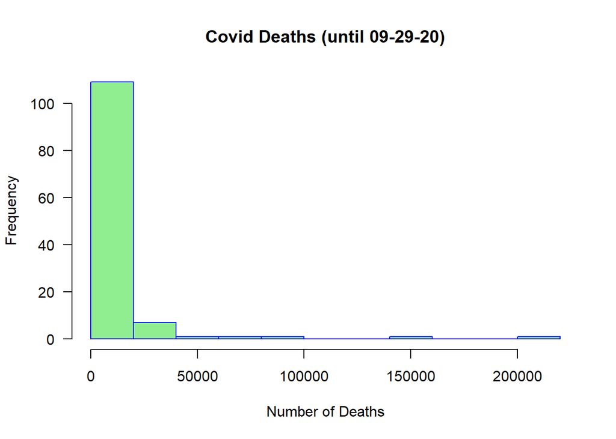

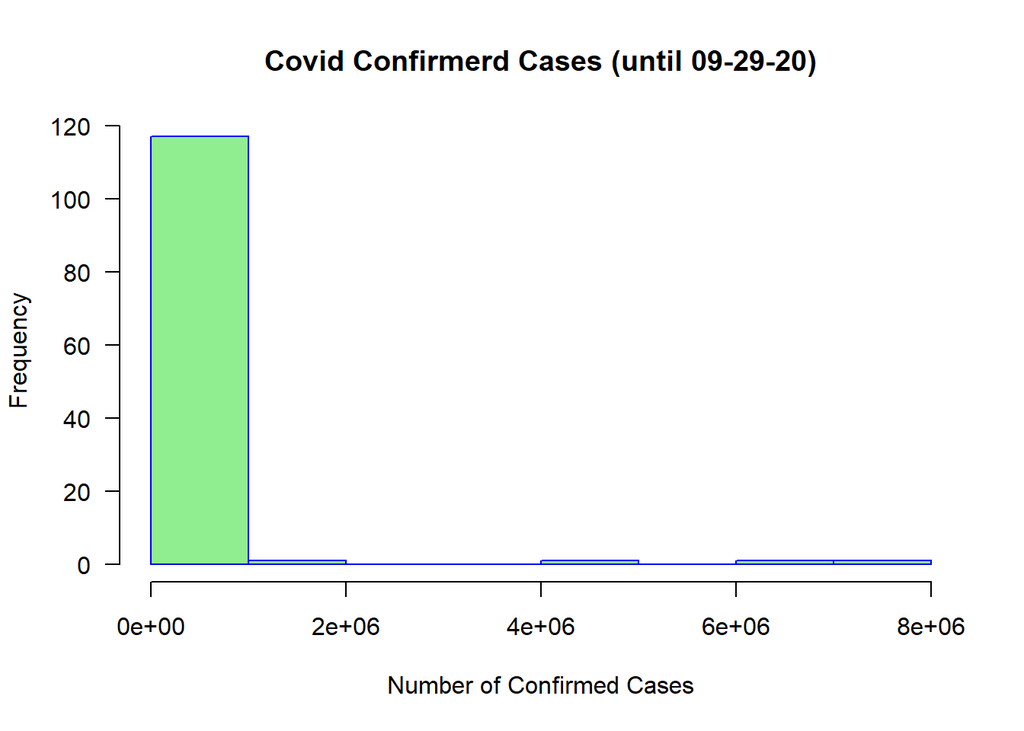

Deaths and Confirmed Cases: Right tail Distributions: median < mean, outliers distributed on the right part of the graph

# Log Transformations

Comparing the p-values (significance) and the R^2 adjusted (highness) for the four types of possible transformations (check the appendix),it´s possible to check that the lvl_lvl and log_log represented the best possible models to choose.  
The models lvl_lvl and log_log showed good p and R^2-Ajusted values,checking the graphs its possible to determine that taking logs will be needed for both cases.Both deaths and confirmed cases are highly right-tailed skewed distributions with a few outliers.  
Although, level is easier to interpret in general, the logs in this case produce a better fit, making the association pattern between them better to identify and analyze.  
Absolute values are not that relevant in both cases.

# Models

Based on model comparison our chosen model is reg4 - Weighted-OLS  
## Substantive:  
- The model demonstrated a really great fit for the dataset, and can be used for prediction  
- The beta parameter states that for the following dataset an increase of 10% on the number of confirmed cases will increase, on average, the number of deaths in 9.4%  
- The alfa in that case represents the mean effect on number of deaths of variables not included in the model.  
## Statistical: - The models showed really similar statistical results (p-values and r-adjusted), capturing the variation really well.  
- As logically expected, the weighted one by population size could demonstrate a even better fit.

# Hypothesis Testing

|  | Estimate | Std. Error | t value | Pr(>\|t\|) | CI Lower | CI Upper | DF |
| --- | --- | --- | --- | --- | --- | --- | --- |
| (Intercept) | -2.905429 | 1.1514831 | -2.523206 | 0.0129479 | -5.1854804 | -0.6253773 | 119 |
| ln_confirmed | 0.943716 | 0.0911494 | 10.353509 | 0.0000000 | 0.7632311 | 1.1242009 | 119 |

Beta coefficient test is equal to 0? Test: H0: = 0, HA: ln_confirmed <> 0 Can reject null hypothesis: equal to 0

# Residual Analysis

## Top 5 Countries with lower death than predicted by regression

| country | ln_death | reg4_y_pred | reg4_res |
| --- | --- | --- | --- |
| Bahrain | 5.505 | 7.629 | -2.123 |
| Maldives | 3.526 | 5.805 | -2.278 |
| Qatar | 5.366 | 8.174 | -2.808 |
| Singapore | 3.296 | 7.441 | -4.145 |
| Slovak Republic | 3.807 | 5.745 | -1.939 |

## Top 5 Countries with higher death than predicted by regression

| country | ln_death | reg4_y_pred | reg4_res |
| --- | --- | --- | --- |
| Belgium | 9.21 | 8.109 | 1.102 |
| Ecuador | 9.334 | 8.248 | 1.086 |
| Italy | 10.49 | 9.036 | 1.451 |
| Mexico | 11.25 | 9.846 | 1.408 |
| United Kingdom | 10.65 | 9.376 | 1.273 |

# Appendix

## Log Transformations Decision

### Check homoskedastic - Breusch-Pagan Test

```r
lvl_lvl <- lm( death ~ confirmed , data = df)
log_lvl <- lm( death ~ ln_confirmed , data = df )
lvl_log <- lm( ln_death ~ confirmed , data = df )
log_log <- lm( ln_death ~ ln_confirmed , data = df )

bptest( lvl_lvl ) # small p-value can´t reject the null hypothesis (homoscedasticity)
```

```
##
##  studentized Breusch-Pagan test
##
## data:  lvl_lvl
## BP = 39.195, df = 1, p-value = 3.835e-10
```

```r
bptest( log_lvl ) # small p-value can´t reject the null hypothesis (homoscedasticity)
```

```
##
##  studentized Breusch-Pagan test
##
## data:  log_lvl
## BP = 18.553, df = 1, p-value = 1.653e-05
```

```r
bptest( lvl_log ) # big p-value can t reject the null hypothesis (homoscedasticity)
```

```
##
##  studentized Breusch-Pagan test
##
## data:  lvl_log
## BP = 2.0841, df = 1, p-value = 0.1488
```

```r
bptest( log_log ) # big p-value can reject the null hypothesis (homoscedasticity)
```

```
##
##  studentized Breusch-Pagan test
##
## data:  log_log
## BP = 0.29231, df = 1, p-value = 0.5887
```

```r
# Use lm_robust lvl_log / log_log
lvl_log <- lm_robust( ln_death ~ confirmed , data = df , se_type = "HC2" )
log_log <- lm_robust( ln_death ~ ln_confirmed , data = df , se_type = "HC2" )
```

### Graphical Check

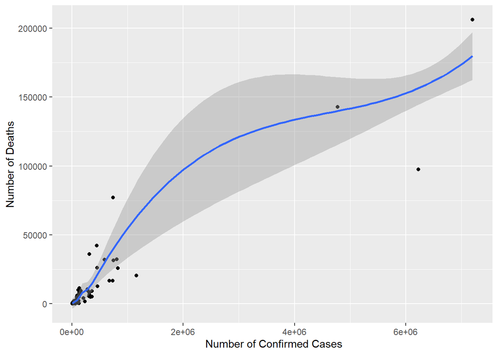

```r
#Death - confirmed : level-level

ggplot( df , aes(x = confirmed , y = death)) +
  geom_point() +
  geom_smooth(method="loess")+
  labs(x = " Number of Confirmed Cases", y = "Number of Deaths")
```

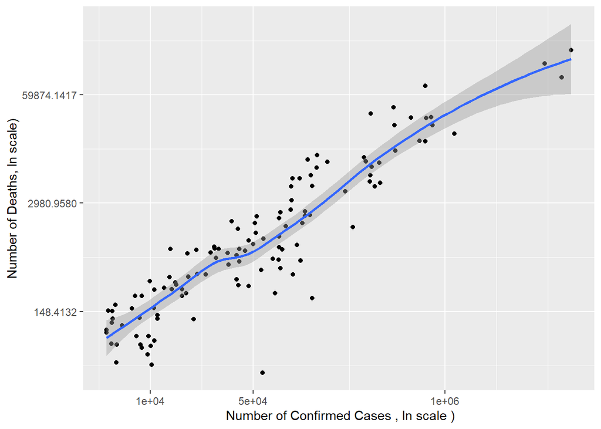

```r
# Death - confirmed : log-log
ggplot( df , aes(x = confirmed, y = death ))  +
  geom_point() +
  geom_smooth(method="loess")+
  labs(x = " Number of Confirmed Cases , ln scale )",y = "Number of Deaths, ln scale)") +
  scale_x_continuous( trans = log_trans(),  breaks = c(10000,50000,1000000))+
  scale_y_continuous( trans = log_trans())
```

Considering the graphs you can definetily see that you reach a better fit using the log_log, instead of the lvl_lvl. The distribution of deaths is a really right-tailed skewed one.

## Model Comparison - Graphs

```
##
## Call:
## lm_robust(formula = ln_death ~ ln_confirmed, data = df, se_type = "HC2")
##
## Standard error type:  HC2
##
## Coefficients:
##              Estimate Std. Error t value  Pr(>|t|) CI Lower CI Upper  DF
## (Intercept)    -5.454    0.39650  -13.76 2.360e-26   -6.240   -4.669 119
## ln_confirmed    1.138    0.03677   30.95 9.413e-59    1.065    1.211 119
##
## Multiple R-squared:  0.8395 ,    Adjusted R-squared:  0.8382
## F-statistic: 957.7 on 1 and 119 DF,  p-value: < 2.2e-16
```

[figure not shown]

```
##
## Call:
## lm_robust(formula = ln_death ~ ln_confirmed + ln_confirmed_sq,
##     data = df)
##
## Standard error type:  HC2
##
## Coefficients:
##                   Estimate Std. Error t value Pr(>|t|)  CI Lower CI Upper  DF
## (Intercept)     -5.5522636    2.50606  -2.216  0.02864 -10.51495 -0.58958 118
## ln_confirmed     1.1555397    0.44522   2.595  0.01065   0.27388  2.03720 118
## ln_confirmed_sq -0.0007698    0.01924  -0.040  0.96816  -0.03888  0.03734 118
##
## Multiple R-squared:  0.8395 ,    Adjusted R-squared:  0.8368
## F-statistic: 472.7 on 2 and 118 DF,  p-value: < 2.2e-16
```

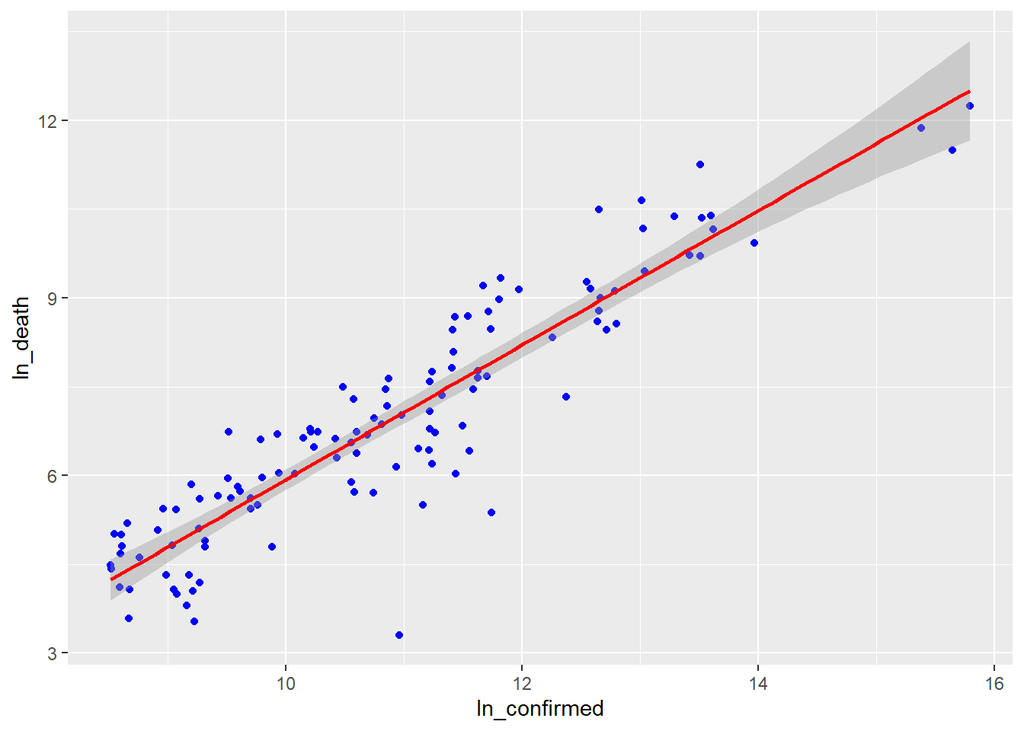

```
##
## Call:
## lm_robust(formula = ln_death ~ lspline(ln_confirmed, cutoff_ln),
##     data = df)
##
## Standard error type:  HC2
##
## Coefficients:
##                                   Estimate Std. Error t value  Pr(>|t|)
## (Intercept)                         -5.728    0.53375 -10.732 3.654e-19
## lspline(ln_confirmed, cutoff_ln)1    1.165    0.05161  22.571 1.239e-44
## lspline(ln_confirmed, cutoff_ln)2    1.007    0.11384   8.848 1.049e-14
##                                   CI Lower CI Upper  DF
## (Intercept)                        -6.7850   -4.671 118
## lspline(ln_confirmed, cutoff_ln)1   1.0626    1.267 118
## lspline(ln_confirmed, cutoff_ln)2   0.7818    1.233 118
##
## Multiple R-squared:  0.8403 ,    Adjusted R-squared:  0.8376
## F-statistic: 617.4 on 2 and 118 DF,  p-value: < 2.2e-16
```

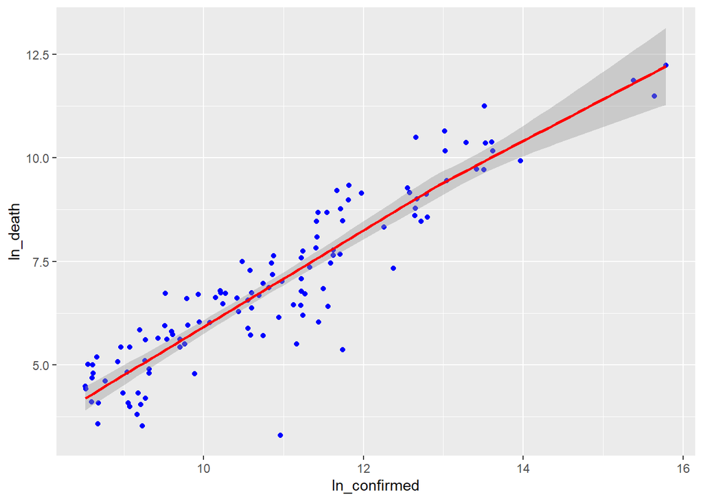

```
##
## Call:
## lm_robust(formula = ln_death ~ ln_confirmed, data = df, weights = population)
##
## Weighted, Standard error type:  HC2
##
## Coefficients:
##              Estimate Std. Error t value  Pr(>|t|) CI Lower CI Upper  DF
## (Intercept)   -2.9054    1.15148  -2.523 1.295e-02  -5.1855  -0.6254 119
## ln_confirmed   0.9437    0.09115  10.354 2.659e-18   0.7632   1.1242 119
##
## Multiple R-squared:  0.9068 ,    Adjusted R-squared:  0.906
## F-statistic: 107.2 on 1 and 119 DF,  p-value: < 2.2e-16
```

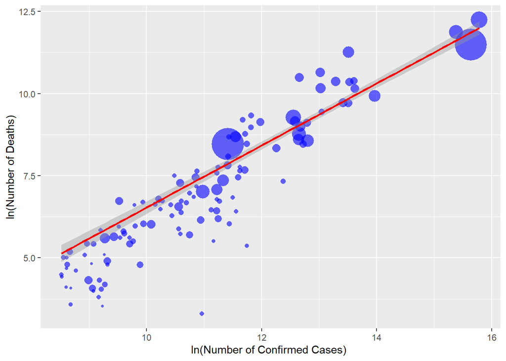

## Model Comparison - HTML

```r
data_out <- 'D:/CEU/Data_Analysis_2/Covid_Assigment_Yuri_Cunha/out/'
htmlreg( list(reg1 , reg2 , reg3 , reg4),
         type = 'html',
         custom.model.names = c("Linear Regression", "Quadratic (Linear) Regression","Piecewise Linear Spline",
                                "Weighted-OLS"),
         caption = "Modelling number of deaths by covid based on number of confirmed cases",
         file = paste0(data_out,'model_comparison.html'), include.ci = FALSE)
```

```
## The table was written to the file 'D:/CEU/Data_Analysis_2/Covid_Assigment_Yuri_Cunha/out/model_comparison.html'.
```

For the analysis, check the main body